# Title: "Project 6 - classification" (y = a2)

(Soufiane Fadel - Razieh Pourhasan)

### Problem description

The ability to monitor and perform early forecasts of various river algae blooms is crucial to control the ecological harm the can cause. The data which is used to train the learning model consists of:

- chemical properties of various water samples of European rivers
- the quantity of seven algae in each of the samples.
- the characteristic of the collection process for each sample.

# Table of contents :

- 1. Pre-processing and Exploring data
  - 1.1 Load libraries
  - 1.2 Loading data
  - 1.3 Filling missing Values
  - 1.4 Visualize data
- 2. Modeling
  - 2.1 Cross validate models
  - 2.2 Hyperparamater tunning for best models
  - 2.3 Plot learning curves
- 3. Ensemble modeling
  - 3.1 Combining models
- 4. Regression problem with calibration plots
  - 4.1 Root mean square error
  - 4.2 CART model
  - 4.3 linear regression model
  - 4.4 MARS model

# 1. Pre-processing and Exploring

```python
from sklearn.preprocessing import Imputer
```

```python
import numpy as np
import pandas as pd
import matplotlib.pyplot as plt
import plotly.graph_objects as go
import seaborn as sns
from sklearn.preprocessing import Imputer
from sklearn import preprocessing
import pandas as pd
import numpy as np
import matplotlib.pyplot as plt
import seaborn as sns
%matplotlib inline
from collections import Counter
from sklearn.ensemble import RandomForestClassifier, AdaBoostClassifier, GradientBoostingClassifier, ExtraTreesClassifier, VotingClassifier
from sklearn.discriminant_analysis import LinearDiscriminantAnalysis
from sklearn.linear_model import LogisticRegression
from sklearn.neighbors import KNeighborsClassifier
from sklearn.tree import DecisionTreeClassifier, DecisionTreeRegressor
from sklearn.neural_network import MLPClassifier
from sklearn.svm import SVC
from sklearn.model_selection import GridSearchCV, cross_val_score, StratifiedKFold, learning_curve
from sklearn.model_selection import train_test_split # Import train_test_split function
from sklearn.naive_bayes import GaussianNB
from sklearn.linear_model import LinearRegression
from sklearn.model_selection import cross_val_score
#pip install --editable git+https://github.com/scikit-learn-contrib/py-earth@v0.2dev#egg=pyearth
from pyearth import Earth

sns.set(style='white', context='notebook', palette='deep')
```

```python
import warnings
warnings.filterwarnings('ignore')
```

### 1.2 Loading data

```python
data = pd.read_csv("algae_blooms.csv")
data.head()
```

|  | season | size | speed | mxPH | mnO2 | Cl | NO3 | NH4 | oPO4 | PO4 | Chla | a1 | a2 | a3 | a4 | a5 | a6 | a7 |
| --- | --- | --- | --- | --- | --- | --- | --- | --- | --- | --- | --- | --- | --- | --- | --- | --- | --- | --- |
| 0 | winter | small | medium | 8.00 | 9.8 | 60.800 | 6.238 | 578.00000 | 105.000 | 170.00000 | 50.0 | 0.0 | 0.0 | 0.0 | 0.0 | 34.2 | 8.3 | 0.0 |
| 1 | spring | small | medium | 8.35 | 8.0 | 57.750 | 1.288 | 370.00000 | 428.750 | 558.75000 | 1.3 | 1.4 | 7.6 | 4.8 | 1.9 | 6.7 | 0.0 | 2.1 |
| 2 | autumn | small | medium | 8.10 | 11.4 | 40.020 | 5.330 | 346.66699 | 125.667 | 187.05701 | 15.6 | 3.3 | 53.6 | 1.9 | 0.0 | 0.0 | 0.0 | 9.7 |
| 3 | spring | small | medium | 8.07 | 4.8 | 77.364 | 2.302 | 98.18200 | 61.182 | 138.70000 | 1.4 | 3.1 | 41.0 | 18.9 | 0.0 | 1.4 | 0.0 | 1.4 |
| 4 | autumn | small | medium | 8.06 | 9.0 | 55.350 | 10.416 | 233.70000 | 58.222 | 97.58000 | 10.5 | 9.2 | 2.9 | 7.5 | 0.0 | 7.5 | 4.1 | 1.0 |

### 1.3 Filling missing Values

```python
data.info()
```

```
<class 'pandas.core.frame.DataFrame'>
RangeIndex: 340 entries, 0 to 339
Data columns (total 18 columns):
season    340 non-null object
size      340 non-null object
speed     340 non-null object
mxPH      338 non-null float64
mnO2      338 non-null float64
Cl        324 non-null float64
NO3       338 non-null float64
NH4       338 non-null float64
oPO4      338 non-null float64
PO4       333 non-null float64
Chla      317 non-null float64
a1        340 non-null float64
a2        340 non-null float64
a3        340 non-null float64
a4        340 non-null float64
a5        340 non-null float64
a6        340 non-null float64
a7        340 non-null float64
dtypes: float64(15), object(3)
memory usage: 47.9+ KB
```

```python
# fill missing values with mean column values
data_num = data.select_dtypes(include=['float64'])
values = data_num.values
imputer = Imputer()
transformed_values = imputer.fit_transform(values)
# count the number of NaN values in each column
print(np.isnan(transformed_values).sum())
```

```
0
```

```python
data[['mxPH',"mnO2","Cl",'NO3',"NH4","oPO4",'PO4','Chla','a1','a2','a3','a4','a5','a6','a7']] = transformed_values
data.info()
```

```
<class 'pandas.core.frame.DataFrame'>
RangeIndex: 340 entries, 0 to 339
Data columns (total 18 columns):
season    340 non-null object
size      340 non-null object
speed     340 non-null object
mxPH      340 non-null float64
mnO2      340 non-null float64
Cl        340 non-null float64
NO3       340 non-null float64
NH4       340 non-null float64
oPO4      340 non-null float64
PO4       340 non-null float64
Chla      340 non-null float64
a1        340 non-null float64
a2        340 non-null float64
a3        340 non-null float64
a4        340 non-null float64
a5        340 non-null float64
a6        340 non-null float64
a7        340 non-null float64
dtypes: float64(15), object(3)
memory usage: 47.9+ KB
```

### 1.4 Visualize data

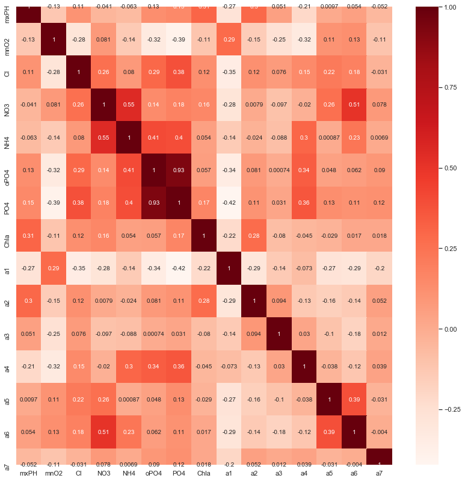

```python
plt.figure(figsize=(14,14))

cor = data.corr()
sns.heatmap(cor, annot=True, cmap=plt.cm.Reds)
plt.show()
```

**NB**

- the chemical properties oPO4 and PO4 are highly correlated so we are going to keep just one of them. (PO4)

```python
data = data.drop(['oPO4', 'a3', 'a4', 'a5', 'a6', 'a7'], axis=1)
data.head()
```

|  | season | size | speed | mxPH | mnO2 | Cl | NO3 | NH4 | PO4 | Chla | a1 | a2 |
| --- | --- | --- | --- | --- | --- | --- | --- | --- | --- | --- | --- | --- |
| 0 | winter | small | medium | 8.00 | 9.8 | 60.800 | 6.238 | 578.00000 | 170.00000 | 50.0 | 0.0 | 0.0 |
| 1 | spring | small | medium | 8.35 | 8.0 | 57.750 | 1.288 | 370.00000 | 558.75000 | 1.3 | 1.4 | 7.6 |
| 2 | autumn | small | medium | 8.10 | 11.4 | 40.020 | 5.330 | 346.66699 | 187.05701 | 15.6 | 3.3 | 53.6 |
| 3 | spring | small | medium | 8.07 | 4.8 | 77.364 | 2.302 | 98.18200 | 138.70000 | 1.4 | 3.1 | 41.0 |
| 4 | autumn | small | medium | 8.06 | 9.0 | 55.350 | 10.416 | 233.70000 | 97.58000 | 10.5 | 9.2 | 2.9 |

```python
import plotly.express as px

#data = data[["season","size.Rate","Metro.Population..millions.","Major.Airports","GDP.Per.Capita..thousands....PPP.rates..per.resident.","Infant.Mortality..Deaths.per.1.000.Births.","Sort_gen.rating","Life.Expectancy.in.Years..Female.","Life.Expectancy.in.Years..Male."]]

plt.figure(figsize=(20,15))
fig = px.parallel_coordinates(data, color="a1",
                              color_continuous_scale=px.colors.diverging.Tealrose,
                              color_continuous_midpoint=2
                              )
fig.show()
```

[interactive chart not shown]

```python
plt.figure(figsize=(20,15))
fig = px.parallel_coordinates(data, color="a2",
                              color_continuous_scale=px.colors.diverging.Tealrose,
                              color_continuous_midpoint=2
                              )
fig.show()
```

[interactive chart not shown]

### converting the targets to classes

```python
sum(data["a2"] == 0)/len(data["a2"])
```

```
0.36176470588235293
```

I'm chossing the threshold for existince of harmful algeas as 0 because :

- 1. by definition of the a2.
- 1. frequency of zeros is about : 36\%

# Models with cross_validation

#### Transforming continuous variable to categorical

```python
threshold = 0
X_train = data[['mxPH',"mnO2","Cl",'NO3',"NH4",'PO4','Chla']]
Y_train = data["a2"]
Y_train = np.array(Y_train)
Y_train = (Y_train > threshold).astype(np.int_)
```

the goal is to choose the best model that fit well our data and to assess how the model learned from training data can be generalized on a new unseen data set we need a way to validate that our model and our hyperparameters are a good fit to the data, and to do so we gonna use the **K-fold cross validation** technique that are frequently used for reducing the overfitting risk.

**The base models to try**

- DecisionTree
- SVC
- RandomForest
- MultipleLayerPerceptron
- Naive Bayes

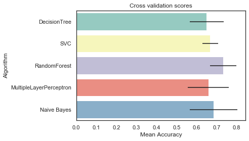

```python
kfold = StratifiedKFold(n_splits=10)

def models_cross_validation(random_state = 2):
    # Modeling step Test differents algorithms

    classifiers = []
    classifiers.append(DecisionTreeClassifier(random_state=random_state))
    classifiers.append(SVC(random_state=random_state))
    classifiers.append(RandomForestClassifier(random_state=random_state))
    classifiers.append(MLPClassifier(random_state=random_state))
    classifiers.append(GaussianNB())
    cv_results = []
    for classifier in classifiers :
        cv_results.append(cross_val_score(classifier, X = X_train, y = Y_train, scoring = "accuracy", cv = kfold, n_jobs=4))

    cv_means = []
    cv_std = []
    for cv_result in cv_results:
        cv_means.append(cv_result.mean())
        cv_std.append(cv_result.std())

    cv_res = pd.DataFrame({"CrossValMeans":cv_means,"CrossValerrors": cv_std,"Algorithm":["DecisionTree","SVC","RandomForest","MultipleLayerPerceptron","Naive Bayes"]})

    g = sns.barplot("CrossValMeans","Algorithm",data = cv_res, palette="Set3",orient = "h",**{'xerr':cv_std})
    g.set_xlabel("Mean Accuracy")
    g = g.set_title("Cross validation scores")



models_cross_validation(random_state = 2)
```

### 2.2 Hyperparamater tunning for best models

```python
def Grid_search_tuning(model,param_grid,X,Y):
    gsmodel = GridSearchCV(model,param_grid = param_grid, cv=kfold, scoring="accuracy", n_jobs= 4, verbose = 1)
    gsmodel.fit(X,Y)
    model_best = gsmodel.best_estimator_
    return model_best,gsmodel.best_score_
```

```python
### SVC classifier
SVMC = SVC(probability=True)
svc_param_grid = {'kernel': ['rbf'],
                  'gamma': [ 0.001, 0.01, 0.1, 1],
                  'C': [1, 10, 50, 100,200,300, 1000]}

### FR classifier
RFC = RandomForestClassifier()
rf_param_grid = {"max_depth": [None],
              "min_samples_split": [2, 3, 10],
              "min_samples_leaf": [1, 3, 10],
              "bootstrap": [False],
              "n_estimators" :[100,300],
              "criterion": ["gini"]}

# Adaboost decision tree
DTC = DecisionTreeClassifier()
adaDTC = AdaBoostClassifier(DTC, random_state=2)
ada_param_grid = {"base_estimator__criterion" : ["gini", "entropy"],
              "base_estimator__splitter" :   ["best", "random"],
              "algorithm" : ["SAMME","SAMME.R"],
              "n_estimators" :[1,2],
              "learning_rate":  [0.0001, 0.001, 0.01, 0.1, 0.2, 0.3,1.5]}

# MLP NN classifier
mlp = MLPClassifier(random_state=2)
parameter_space_mlp = {
    'hidden_layer_sizes': [(50,50,50), (50,100,50), (100,)],
    'activation': ['tanh', 'relu'],
    'solver': ['sgd', 'adam'],
    'alpha': [0.0001, 0.05],
    'learning_rate': ['constant','adaptive'],
}

# NAIVE BAYES CLASSIFIER
nb = GaussianNB()
parameter_space_nb = {
    'var_smoothing': [1e-09, 1e-07,1e-05,1e-03,1e-01],
}


model_best_svm,gs_svm = Grid_search_tuning(SVMC,svc_param_grid,X_train,Y_train)
model_best_RF,gs_RF = Grid_search_tuning(RFC,rf_param_grid,X_train,Y_train)
model_best_adaDT,gs_adaDT= Grid_search_tuning(adaDTC,ada_param_grid,X_train,Y_train)
model_best_MLP,gs_MLP= Grid_search_tuning(mlp,parameter_space_mlp,X_train,Y_train)
model_best_nb,gs_nb= Grid_search_tuning(nb,parameter_space_nb,X_train,Y_train)
```

```
Fitting 10 folds for each of 28 candidates, totalling 280 fits
```

```
[Parallel(n_jobs=4)]: Using backend LokyBackend with 4 concurrent workers.
[Parallel(n_jobs=4)]: Done 212 tasks      | elapsed:    5.0s
[Parallel(n_jobs=4)]: Done 280 out of 280 | elapsed:    6.0s finished
[Parallel(n_jobs=4)]: Using backend LokyBackend with 4 concurrent workers.
```

```
Fitting 10 folds for each of 18 candidates, totalling 180 fits
```

```
[Parallel(n_jobs=4)]: Done  42 tasks      | elapsed:    5.6s
[Parallel(n_jobs=4)]: Done 180 out of 180 | elapsed:   29.9s finished
```

```
Fitting 10 folds for each of 112 candidates, totalling 1120 fits
```

```
[Parallel(n_jobs=4)]: Using backend LokyBackend with 4 concurrent workers.
[Parallel(n_jobs=4)]: Done 1120 out of 1120 | elapsed:    3.6s finished
[Parallel(n_jobs=4)]: Using backend LokyBackend with 4 concurrent workers.
```

```
Fitting 10 folds for each of 48 candidates, totalling 480 fits
```

```
[Parallel(n_jobs=4)]: Done  42 tasks      | elapsed:   10.7s
[Parallel(n_jobs=4)]: Done 192 tasks      | elapsed:   50.8s
[Parallel(n_jobs=4)]: Done 442 tasks      | elapsed:  1.4min
[Parallel(n_jobs=4)]: Done 480 out of 480 | elapsed:  1.5min finished
```

```
Fitting 10 folds for each of 5 candidates, totalling 50 fits
```

```
[Parallel(n_jobs=4)]: Using backend LokyBackend with 4 concurrent workers.
[Parallel(n_jobs=4)]: Done  50 out of  50 | elapsed:    0.2s finished
```

```python
print("the best accuracy for SVM is : " + str(gs_svm))
print("the best accuracy for RF is : " + str(gs_RF))
print("the best accuracy for ada_desicion_tree is : " + str(gs_adaDT))
print("the best accuracy for MLP is : " + str(gs_MLP))
print("the best accuracy for naive bayes is : " + str(gs_nb) )
```

```
the best accuracy for SVM is : 0.7441176470588236
the best accuracy for RF is : 0.7705882352941177
the best accuracy for ada_desicion_tree is : 0.6970588235294117
the best accuracy for MLP is : 0.7029411764705882
the best accuracy for naive bayes is : 0.6852941176470588
```

### 2.3 Plot learning curves

A learning curve shows the validation and training score of an estimator for varying numbers of training samples. It is a tool to find out how much we benefit from adding more training data and whether the estimator suffers more from a variance error or a bias error.

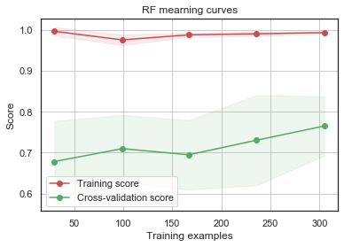

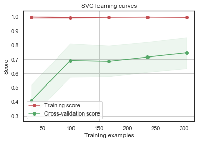

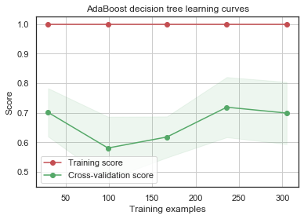

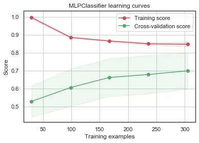

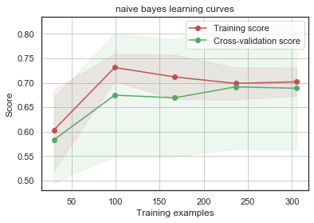

```python
def plot_learning_curve(estimator, title, X, y, ylim=None, cv=None,
                        n_jobs=-1, train_sizes=np.linspace(.1, 1.0, 5)):
    """Generate a simple plot of the test and training learning curve"""
    plt.figure()
    plt.title(title)
    if ylim is not None:
        plt.ylim(*ylim)
    plt.xlabel("Training examples")
    plt.ylabel("Score")
    train_sizes, train_scores, test_scores = learning_curve(
        estimator, X, y, cv=cv, n_jobs=n_jobs,scoring="accuracy", train_sizes=train_sizes)
    train_scores_mean = np.mean(train_scores, axis=1)
    train_scores_std = np.std(train_scores, axis=1)
    test_scores_mean = np.mean(test_scores, axis=1)
    test_scores_std = np.std(test_scores, axis=1)
    plt.grid()

    plt.fill_between(train_sizes, train_scores_mean - train_scores_std,
                     train_scores_mean + train_scores_std, alpha=0.1,
                     color="r")
    plt.fill_between(train_sizes, test_scores_mean - test_scores_std,
                     test_scores_mean + test_scores_std, alpha=0.1, color="g")
    plt.plot(train_sizes, train_scores_mean, 'o-', color="r",
             label="Training score")
    plt.plot(train_sizes, test_scores_mean, 'o-', color="g",
             label="Cross-validation score")

    plt.legend(loc="best")
    return plt

g = plot_learning_curve(model_best_RF,"RF mearning curves",X_train,Y_train,cv=kfold)
g = plot_learning_curve(model_best_svm,"SVC learning curves",X_train,Y_train,cv=kfold)
g = plot_learning_curve(model_best_adaDT,"AdaBoost decision tree learning curves",X_train,Y_train,cv=kfold)
g = plot_learning_curve(model_best_MLP,"MLPClassifier learning curves",X_train,Y_train,cv=kfold)
g = plot_learning_curve(model_best_nb,"naive bayes learning curves",X_train,Y_train,cv=kfold)
```

# 3. Ensemble modeling

### 3.1 splitting data

```python
x_train, x_test, y_train, y_test = train_test_split(X_train, Y_train, test_size=0.2, random_state=1) # 80% training and 30% test
```

### 3.2 Combining models

```python
votingC = VotingClassifier(estimators=[('rfc', model_best_RF),
                                       ('svmc', model_best_svm),
                                       ('adadtc', model_best_adaDT),
                                       ('mlpc',model_best_MLP),
                                       ('nbc',model_best_nb)
                                        ],
                                       voting='soft',
                                       n_jobs=4)

votingC = votingC.fit(x_train, y_train)
```

```python
test_Survived = pd.Series(votingC.predict(x_test), name="Survived")
y_test = pd.Series(y_test)
acc = sum(y_test==test_Survived)/len(y_test)
print("the accuracy for the combined model is : " + str(acc))
```

```
the accuracy for the combined model is : 0.7941176470588235
```

# 4. Regression problem with calibration plots

From the 5-fold cross validation analysis... we showed the preformence of the regressor models for this data and we evaluate the results with the next Calibration curve plots.

### 4.1 Root mean square error

```python
X_train = data[['mxPH',"mnO2","Cl",'NO3',"NH4",'PO4','Chla']]
Y_train = data["a2"]

def rmse_cv(model):
    rmse= np.sqrt(-cross_val_score(model, X_train, Y_train, scoring="neg_mean_squared_error", cv = 5))
    return(rmse)
```

### 4.2 CART model

```python
dtr = DecisionTreeRegressor()
cv_dtr = rmse_cv(dtr).mean()
print("the Root mean square error for the Decision Tree Regressor (CART model)  is : " + str(cv_dtr))
```

```
the Root mean square error for the Decision Tree Regressor (CART model)  is : 13.231598753854385
```

### calibration plot

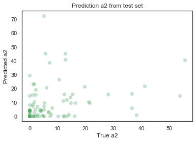

```python
x_train, x_test,y_train, y_test = train_test_split(X_train, Y_train, train_size=0.7, random_state = 2)
dtr = DecisionTreeRegressor()

dtr_fit = dtr.fit(x_train, y_train)
X_test_pred = dtr.predict(x_test)
X_train_pred = dtr.predict(x_train)
df_sca_train = pd.DataFrame(y_train)
df_sca_train['X_train_pred'] = X_train_pred

df_sca = pd.DataFrame()
df_sca['y_test']= y_test
df_sca['X_test_pred'] = X_test_pred

plt.scatter(y_test, X_test_pred, alpha=0.3, c='g')
plt.title('Prediction a2 from test set')
plt.xlabel('True a2')
plt.ylabel('Predicted a2')
plt.show()
```

### 4.3 linear regression model

```python
lrm = LinearRegression()
cv_lrm = rmse_cv(lrm).mean()
print("the Root mean square error for linear regression model  is : " + str(cv_lrm))
```

```
the Root mean square error for linear regression model  is : 10.329382389824493
```

### calibration plot

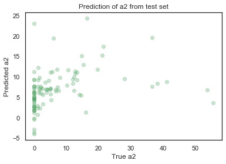

```python
X_train = data[['mxPH',"mnO2","Cl",'NO3',"NH4",'PO4','Chla']]
Y_train = data["a2"]
x_train, x_test,y_train, y_test = train_test_split(X_train, Y_train, train_size=0.7, random_state = 2)
lrm = LinearRegression()

lrm_fit = lrm.fit(x_train, y_train)
X_test_pred = lrm.predict(x_test)
X_train_pred = lrm.predict(x_train)
df_sca_train = pd.DataFrame(y_train)
df_sca_train['X_train_pred'] = X_train_pred

df_sca = pd.DataFrame()
df_sca['y_test']= y_test
df_sca['X_test_pred'] = X_test_pred

plt.scatter(y_test, X_test_pred, alpha=0.3, c='g')
plt.title('Prediction of a2 from test set')
plt.xlabel('True a2')
plt.ylabel('Predicted a2')
plt.show()
```

### 4.4 MARS model

```python
mars = Earth(max_degree=1, penalty=1.0, endspan=5)
cv_mars = rmse_cv(mars).mean()
print("the Root mean square error for MARS model is : " + str(cv_mars))
```

```
the Root mean square error for MARS model is : 10.116343765275266
```

### calibration plot

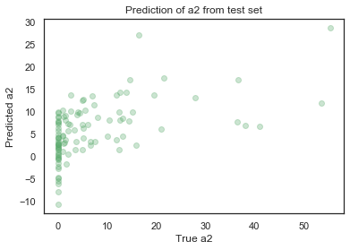

```python
X_train = data[['mxPH',"mnO2","Cl",'NO3',"NH4",'PO4','Chla']]
Y_train = data["a2"]
x_train, x_test,y_train, y_test = train_test_split(X_train, Y_train, train_size=0.7, random_state = 2)
mars = Earth(max_degree=1, penalty=1.0, endspan=5)

mars_fit = mars.fit(x_train, y_train)
X_test_pred = mars.predict(x_test)
X_train_pred = mars.predict(x_train)
df_sca_train = pd.DataFrame(y_train)
df_sca_train['X_train_pred'] = X_train_pred

df_sca = pd.DataFrame()
df_sca['y_test']= y_test
df_sca['X_test_pred'] = X_test_pred

plt.scatter(y_test, X_test_pred, alpha=0.3, c='g')
plt.title('Prediction of a2 from test set')
plt.xlabel('True a2')
plt.ylabel('Predicted a2')
plt.show()
```